# Pilot Analyses

# Descriptives

## Overall

```r
descrip_overall <- psych::describe(clean_data)
descrip_overall
```

```
##                         vars   n   mean     sd median trimmed   mad min  max
## subid*                     1 209 124.95  73.19    128  125.15 91.92   1  248
## progress                   2 209 100.00   0.00    100  100.00  0.00 100  100
## duration_sec               3 209 231.56 126.41    203  212.28 84.51  86 1072
## finished                   4 209   1.00   0.00      1    1.00  0.00   1    1
## recorded_date              5 209    NaN     NA     NA     NaN    NA Inf -Inf
## consent*                   6 209   1.00   0.00      1    1.00  0.00   1    1
## vote_check*                7 209   1.00   0.00      1    1.00  0.00   1    1
## condition*                 8 209   2.93   1.41      3    2.92  1.48   1    5
## manip_check_politics*      9 209   3.48   0.50      3    3.47  0.00   3    4
## manip_check_covid*        10 209   2.78   0.41      3    2.85  0.00   2    3
## manip_check_profess*      11 209   3.24   0.72      3    3.30  1.48   2    4
## jen_check*                12 209   2.00   0.00      2    2.00  0.00   2    2
## distance_coffee           13 209   3.83   0.96      4    3.90  1.48   1    5
## distance_town             14 209   3.75   1.64      4    3.60  1.48   1    7
## realistic_q               15 209   2.87   1.14      3    2.95  1.48   1    4
## symbolic_q                16 209   2.86   1.14      3    2.94  1.48   1    4
## explicit_targ             17 209   2.39   1.12      2    2.36  1.48   1    4
## explicit_group            18 209   3.11   0.91      3    3.20  1.48   1    4
## pol_orient_1              19 209   1.77   0.68      2    1.70  0.00   1    4
## pol_orient_2              20 209   1.52   0.72      1    1.39  0.00   1    4
## pol_orient_3              21 209   2.02   0.98      2    1.89  1.48   1    5
## age                       22 209  35.10  12.84     31   33.51 10.38  19   82
## gender*                   23 209   2.36   0.92      3    2.44  0.00   1    3
## gender_3_TEXT*            24 209   1.07   0.51      1    1.00  0.00   1    6
## education*                25 209   4.05   2.31      4    4.02  2.97   1    8
## parent_education*         26 209   4.15   2.11      4    4.15  2.97   1    8
## race*                     27 209   5.17   1.46      6    5.45  0.00   1    6
## race_7_TEXT*              28 209   1.05   0.38      1    1.00  0.00   1    5
## race_8_TEXT               29   0    NaN     NA     NA     NaN    NA Inf -Inf
## country_birth*            30 209   1.94   0.24      2    2.00  0.00   1    2
## country_birth_2_TEXT*     31 209   1.27   1.34      1    1.00  0.00   1   11
## country_raised*           32 209   1.98   0.15      2    2.00  0.00   1    2
## country_raised_2_TEXT*    33 209   1.03   0.26      1    1.00  0.00   1    4
## raised_follow*            34 209   1.07   0.51      1    1.00  0.00   1    6
## native_language*          35 209   1.06   0.23      1    1.00  0.00   1    2
## native_language_2_TEXT*   36 209   1.26   1.30      1    1.00  0.00   1   10
## native_lang_follow*       37 209   2.07   3.65      1    1.01  0.00   1   21
## q_check_politics*         38 209   1.06   0.23      1    1.00  0.00   1    2
## q_check_covid*            39 209   1.00   0.00      1    1.00  0.00   1    1
```

[output cut: 27 more lines]

```
## parent_education*           7  0.05    -1.45 0.15
## race*                       5 -1.40     0.30 0.10
## race_7_TEXT*                4  8.57    76.63 0.03
## race_8_TEXT              -Inf    NA       NA   NA
## country_birth*              1 -3.60    11.01 0.02
## country_birth_2_TEXT*      10  5.42    29.97 0.09
## country_raised*             1 -6.19    36.44 0.01
## country_raised_2_TEXT*      3  9.72    98.70 0.02
## raised_follow*              5  7.73    62.22 0.04
## native_language*            1  3.78    12.33 0.02
## native_language_2_TEXT*     9  5.38    29.05 0.09
## native_lang_follow*        20  3.60    12.24 0.25
## q_check_politics*           1  3.78    12.33 0.02
## q_check_covid*              0   NaN      NaN 0.00
## q_check_profess*            0   NaN      NaN 0.00
```

## Sample size

```r
clean_data %>%
  select(subid) %>%
  unique() %>%
  nrow()
```

```
## [1] 209
```

### Per condition

```r
clean_data %>%
  select(subid, condition) %>%
  unique() %>%
  group_by(condition) %>%
  count()
```

```
## # A tibble: 5 × 2
## # Groups:   condition [5]
##   condition        n
##   <fct>        <int>
## 1 control_targ    43
## 2 warm_targ       45
## 3 covid_targ      45
## 4 comp_targ       35
## 5 loss_targ       41
```

A lot were removed from the competitive target in comparison to the other conditions.

### Participants who got manipulation check “somewhat correct”

```r
clean_data %>%
  mutate(q_check_politics = as.factor(q_check_politics)) %>%
  filter(q_check_politics == "Somewhat correct") %>%
  count()
```

```
##    n
## 1 12
```

## Histograms

### Distance in coffee shop

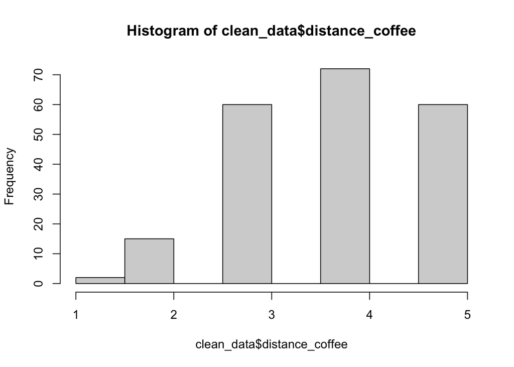

```r
hist(clean_data$distance_coffee)
```

Seat E is option “5,” or the farthest seat away. It is left/negative-skewed to this option.

#### Is the skew non-normal?

```r
se_skew <- sqrt((6*211*(211-1))/((211-2)*(211+1)*(211+3)))
z_coffee <- descrip_overall$skew[13]/se_skew
z_coffee
```

```
## [1] -2.382194
```

Formula used for se of skew: se_skew = sqrt(6*N*(N-1) / ((N-2)*(N+1)*(N+3)))

https://www.ibm.com/support/pages/standard-errors-skewness-and-kurtosis-are-all-same-set-variables

Committee member (Sara W) also informed me that unless I was missing responses for one answer entirely on one side, the skew is not something to be concerned about. I am keeping this test here as a reference for future, but am removing other z tests for skew below because none meet the observational skew test Sara suggested.

### Distance in town

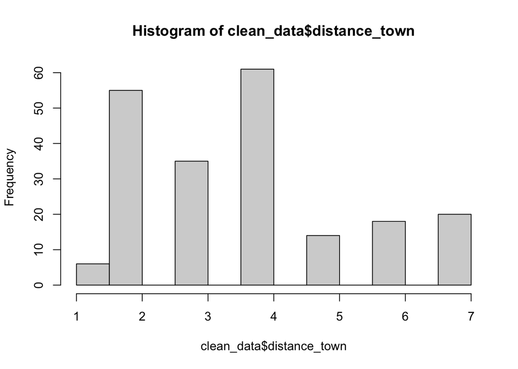

```r
hist(clean_data$distance_town)
```

Right skewed (not as far of a distance), kind of plateaus at option 5. Still normal skew.

### Realistic threat

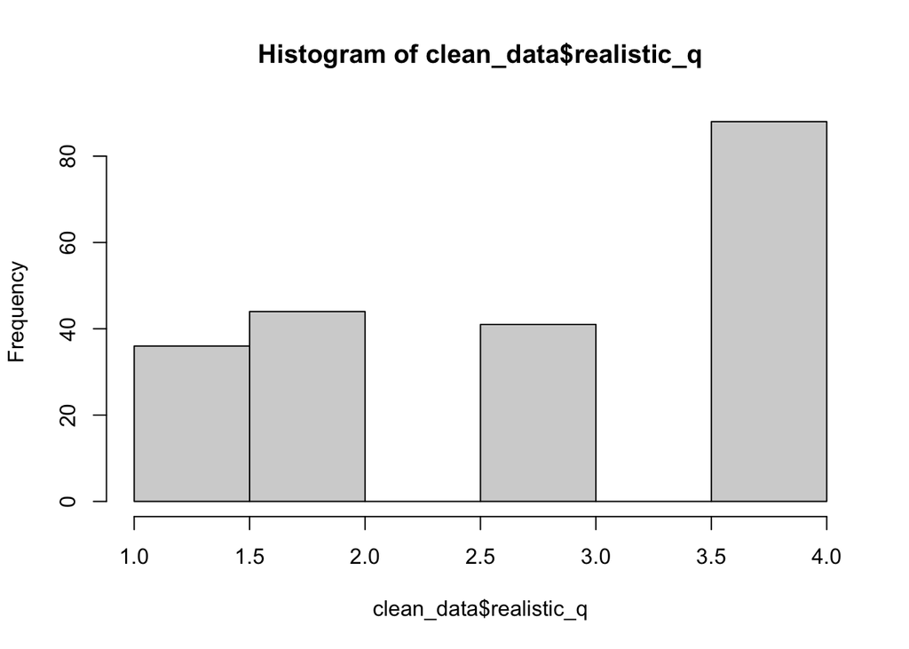

```r
hist(clean_data$realistic_q)
```

Left/negative-skewed, with 4 = “Extremely threatening.” I don’t think this is concerning because it shows people are experiencing more threat overall and we had more threatening conditions than not. Skew is normal.

### Symbolic threat

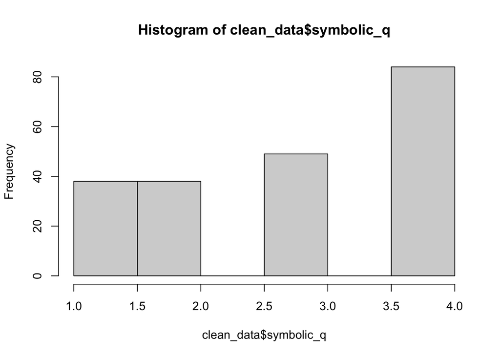

```r
hist(clean_data$symbolic_q)
```

Left/negative-skewed, same as with realistic threat above. Skew is normal.

### Explicit threat posed by target

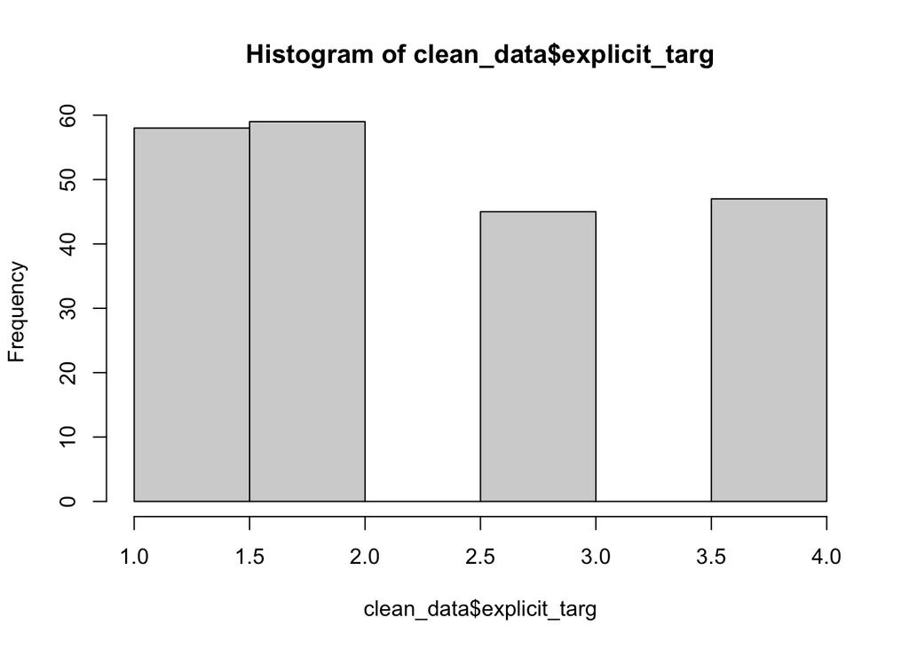

```r
hist(clean_data$explicit_targ)
```

Looks evenly spread out.

### Explicit threat posed by political out-group

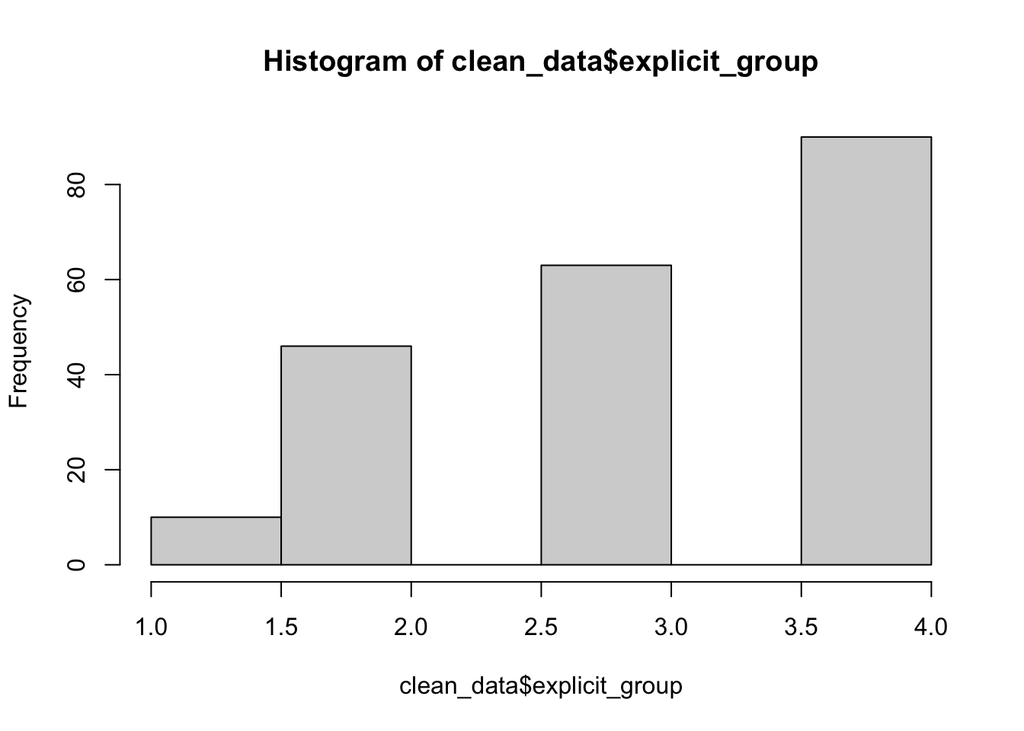

```r
hist(clean_data$explicit_group)
```

Left/negative skew. Seems people are more willing to discuss explicit threat of the group than the individual. Skew is normal.

### Political orientation

#### Overall

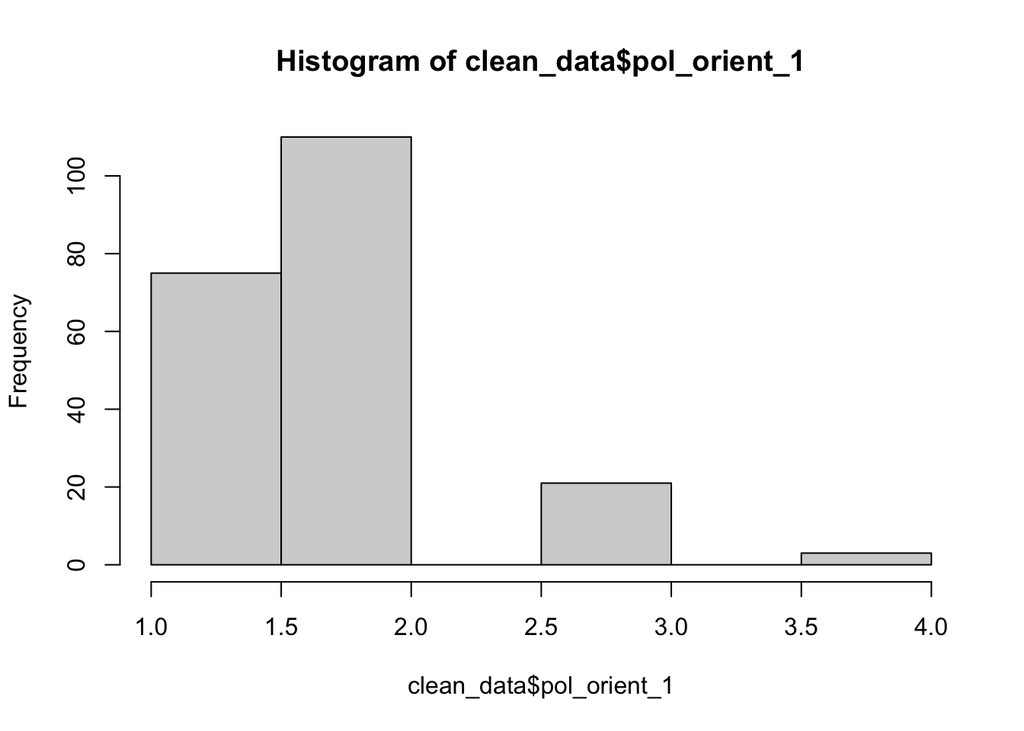

```r
hist(clean_data$pol_orient_1)
```

```r
clean_data %>%
  group_by(pol_orient_1) %>%
  count()
```

```
## # A tibble: 4 × 2
## # Groups:   pol_orient_1 [4]
##   pol_orient_1     n
##          <dbl> <int>
## 1            1    75
## 2            2   110
## 3            3    21
## 4            4     3
```

Right/positive-skewed, not surprising as filtered for liberals and 1 = “extremely liberal.” Skew is normal.

#### Social

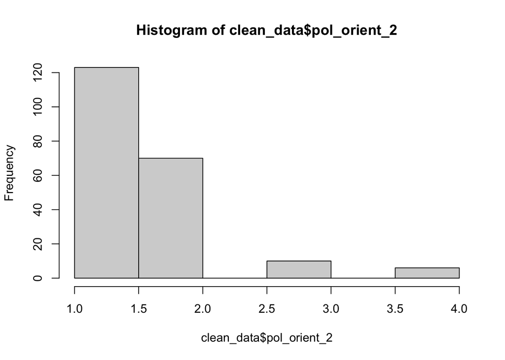

```r
hist(clean_data$pol_orient_2)
```

```r
clean_data %>%
  group_by(pol_orient_2) %>%
  count()
```

```
## # A tibble: 4 × 2
## # Groups:   pol_orient_2 [4]
##   pol_orient_2     n
##          <dbl> <int>
## 1            1   123
## 2            2    70
## 3            3    10
## 4            4     6
```

Right/positive-skewed, still not surprised for the same reasons. Skew is normal.

#### Economic

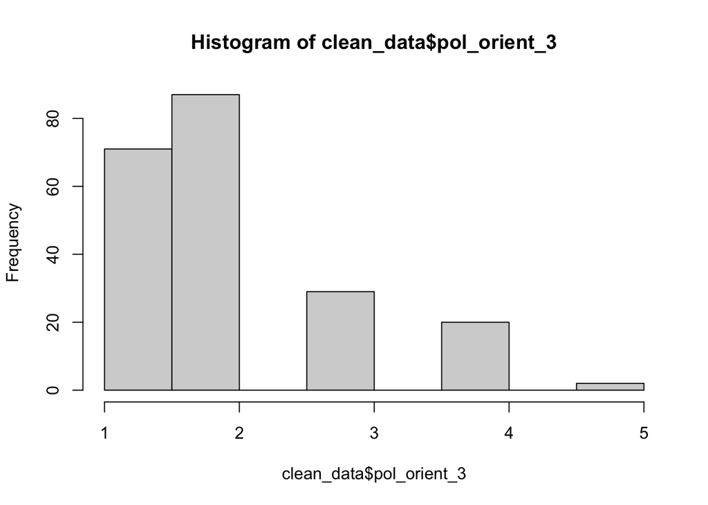

```r
hist(clean_data$pol_orient_3)
```

```r
clean_data %>%
  group_by(pol_orient_3) %>%
  count()
```

```
## # A tibble: 5 × 2
## # Groups:   pol_orient_3 [5]
##   pol_orient_3     n
##          <dbl> <int>
## 1            1    71
## 2            2    87
## 3            3    29
## 4            4    20
## 5            5     2
```

Right/positive-skewed. Skew is normal.

# Scale validation

## Correlation matrix

```r
# Getting only the variables in order to do an EFA
efa_data <- clean_data %>%
  select(distance_coffee, distance_town, realistic_q, symbolic_q)

cor_matrix <- cor(efa_data)
cor_matrix
```

```
##                 distance_coffee distance_town realistic_q symbolic_q
## distance_coffee      1.00000000   -0.03391112   0.3246110  0.2850587
## distance_town       -0.03391112    1.00000000   0.1634243  0.1526149
## realistic_q          0.32461102    0.16342429   1.0000000  0.8339753
## symbolic_q           0.28505872    0.15261492   0.8339753  1.0000000
```

## EFA

### What number of factors are advisable?

```r
# What is the most recommended number of EFA factors?
factors_exp <- n_factors(efa_data)
factors_exp
```

```
## # Method Agreement Procedure:
##
## The choice of 1 dimensions is supported by 5 (33.33%) methods out of 15 (Optimal coordinates, Acceleration factor, Velicer's MAP, BIC, BIC (adjusted)).
```

```r
# How many factors are supported by what number of methods?
summary(factors_exp)
```

```
##   n_Factors n_Methods
## 1         0         2
## 2         1         5
## 3         2         4
## 4         3         3
## 5         4         1
```

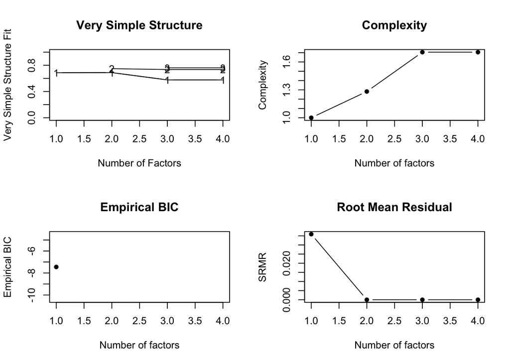

```
##
## Number of factors
## Call: vss(x = x, n = n, rotate = rotate, diagonal = diagonal, fm = fm,
##     n.obs = n.obs, plot = FALSE, title = title, use = use, cor = cor)
## VSS complexity 1 achieves a maximimum of 0.69  with  2  factors
## VSS complexity 2 achieves a maximimum of 0.75  with  2  factors
## The Velicer MAP achieves a minimum of 0.13  with  1  factors
## Empirical BIC achieves a minimum of  -7.45  with  1  factors
## Sample Size adjusted BIC achieves a minimum of  -2.22  with  1  factors
##
## Statistics by number of factors
##   vss1 vss2  map dof          chisq prob sqresid  fit RMSEA  BIC SABIC complex
## 1 0.69 0.00 0.13   2 2.128663263351 0.34     1.8 0.69 0.017 -8.6  -2.2     1.0
## 2 0.69 0.75 0.46  -1 0.000000034541   NA     1.5 0.75    NA   NA    NA     1.3
## 3 0.58 0.74 1.00  -3 0.000000000002   NA     1.4 0.76    NA   NA    NA     1.7
## 4 0.58 0.74   NA  -4 0.000000000002   NA     1.4 0.76    NA   NA    NA     1.7
##             eChisq        SRMR eCRMS eBIC
## 1 3.23448635158805 0.035911942 0.062 -7.5
## 2 0.00000001149335 0.000002141    NA   NA
## 3 0.00000000000047 0.000000014    NA   NA
## 4 0.00000000000047 0.000000014    NA   NA
```

```r
nfactors(efa_data)
```

It appears that 1 factor (as we planned) or maybe 2 factors are most advisable!

### 1 Factor EFA

```r
efa_1fac <- psych::fa(efa_data, nfactors = 1)

efa_1fac %>%
  model_parameters(sort = TRUE, threshold = "max")
```

```
## # Rotated loadings from Factor Analysis (oblimin-rotation)
##
## Variable        | MR1  | Complexity | Uniqueness
## ------------------------------------------------
## realistic_q     | 0.98 |    1.00    |    0.05
## symbolic_q      | 0.86 |    1.00    |    0.26
## distance_coffee | 0.32 |    1.00    |    0.89
## distance_town   | 0.16 |    1.00    |    0.98
##
## The unique latent factor (oblimin rotation) accounted for 45.53% of the total variance of the original data.
```

With the correlations not being as high for the distance measures and their respective factor loadings also being low on the one factor EFA, it appears that 1 factor with just realistic and symbolic threat is most advisable. The distance measures will be explored separately.

## Cronbach’s alpha

### Alpha with realistic and symbolic

```r
efa_itt <- efa_data %>%
  select(-distance_town, -distance_coffee)

psych::alpha(efa_itt)
```

```
##
## Reliability analysis
## Call: psych::alpha(x = efa_itt)
##
##   raw_alpha std.alpha G6(smc) average_r S/N   ase mean  sd median_r
##       0.91      0.91    0.83      0.83  10 0.013  2.9 1.1     0.83
##
##     95% confidence boundaries
##          lower alpha upper
## Feldt     0.88  0.91  0.93
## Duhachek  0.88  0.91  0.93
##
##  Reliability if an item is dropped:
##             raw_alpha std.alpha G6(smc) average_r S/N alpha se var.r med.r
## realistic_q      0.84      0.83     0.7      0.83   5       NA     0  0.83
## symbolic_q       0.83      0.83     0.7      0.83   5       NA     0  0.83
##
##  Item statistics
##               n raw.r std.r r.cor r.drop mean  sd
## realistic_q 209  0.96  0.96  0.87   0.83  2.9 1.1
## symbolic_q  209  0.96  0.96  0.87   0.83  2.9 1.1
##
## Non missing response frequency for each item
##                1    2    3    4 miss
## realistic_q 0.17 0.21 0.20 0.42    0
## symbolic_q  0.18 0.18 0.23 0.40    0
```

Intergroup threat theory (realistic and symbolic threat) measures are highly reliable, which is consistent with correlations and EFA results.

```r
efa_distance <- efa_data %>%
  select(distance_town,  distance_coffee)

psych::alpha(efa_distance)
```

```
## Some items ( distance_town ) were negatively correlated with the total scale and
## probably should be reversed.
## To do this, run the function again with the 'check.keys=TRUE' option
```

```
##
## Reliability analysis
## Call: psych::alpha(x = efa_distance)
##
##   raw_alpha std.alpha G6(smc) average_r    S/N  ase mean   sd median_r
##     -0.061     -0.07  -0.034    -0.034 -0.066 0.13  3.8 0.94   -0.034
##
##     95% confidence boundaries
##          lower alpha upper
## Feldt    -0.39 -0.06  0.19
## Duhachek -0.31 -0.06  0.19
##
##  Reliability if an item is dropped:
##                 raw_alpha std.alpha G6(smc) average_r    S/N alpha se var.r
## distance_town      -0.058    -0.034  0.0011    -0.034 -0.033       NA     0
## distance_coffee    -0.020    -0.034  0.0011    -0.034 -0.033       NA     0
##                  med.r
## distance_town   -0.034
## distance_coffee -0.034
##
##  Item statistics
##                   n raw.r std.r r.cor r.drop mean   sd
## distance_town   209  0.86   0.7   NaN -0.034  3.7 1.64
## distance_coffee 209  0.48   0.7   NaN -0.034  3.8 0.96
##
## Non missing response frequency for each item
##                    1    2    3    4    5    6   7 miss
## distance_town   0.03 0.26 0.17 0.29 0.07 0.09 0.1    0
## distance_coffee 0.01 0.07 0.29 0.34 0.29 0.00 0.0    0
```

Distance measures not reliable together, which seems consistent with EFA results. They represent two separate factors. They will each need to be tested individually.

## Current Thoughts

- Primary measure of threat will be a composite (average) of realistic and symbolic threat
- All analyses will also be predicted by distance measures to see how they vary; same goes for explicit threat measures

# Relationship with explicit threat

```r
threat_all <- clean_data %>%
  select(distance_coffee, distance_town, realistic_q, symbolic_q, explicit_targ,
         explicit_group) %>%
  rename("Distance: Coffee" = distance_coffee,
         "Distance: Town" = distance_town,
         "Realistic" = realistic_q,
         "Symbolic" = symbolic_q,
         "Explicit: Target" = explicit_targ,
         "Explicit: Group" = explicit_group)
cor_matrix_all <- cor(threat_all)
cor_matrix_all
```

```
##                  Distance: Coffee Distance: Town Realistic  Symbolic
## Distance: Coffee       1.00000000    -0.03391112 0.3246110 0.2850587
## Distance: Town        -0.03391112     1.00000000 0.1634243 0.1526149
## Realistic              0.32461102     0.16342429 1.0000000 0.8339753
## Symbolic               0.28505872     0.15261492 0.8339753 1.0000000
## Explicit: Target       0.36726404     0.22665406 0.7667831 0.7128681
## Explicit: Group        0.22017084     0.03554288 0.4246107 0.3629113
##                  Explicit: Target Explicit: Group
## Distance: Coffee        0.3672640      0.22017084
## Distance: Town          0.2266541      0.03554288
## Realistic               0.7667831      0.42461069
## Symbolic                0.7128681      0.36291134
## Explicit: Target        1.0000000      0.59271026
## Explicit: Group         0.5927103      1.00000000
```

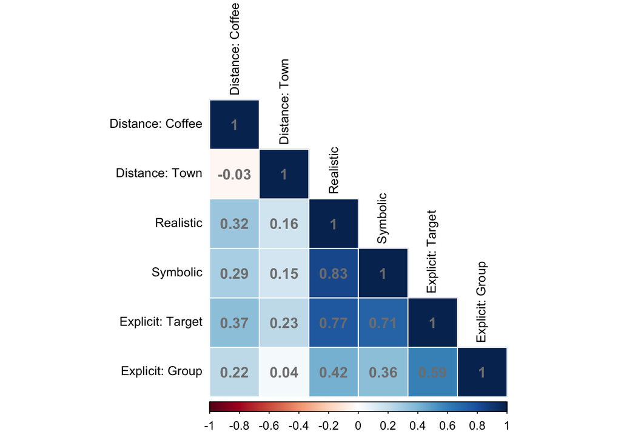

```r
corrplot(cor_matrix_all,
        method = "color",
        tl.cex = .85,
         tl.col = 'black',
         addgrid.col = 'white',
         addCoef.col = 'grey50',
        type = 'lower')
```

The high correlations with explicit threat, though not expected, validate our measures of symbolic and realistic threat.

# ANOVA: Conditions prediciting threat

## Implicit threat: Realistic and Symbolic

Currently using a composite supported by my EFA above, combining realistic threat, and symbolic threat.

```r
clean_data %<>%
  mutate(itt_comp = rowMeans(select(., c("realistic_q", "symbolic_q"))))
```

### Mean

```r
mean(clean_data$itt_comp)
```

```
## [1] 2.861244
```

### SD

```r
sd(clean_data$itt_comp)
```

```
## [1] 1.092976
```

### Range

```r
range(clean_data$itt_comp)
```

```
## [1] 1 4
```

### ANOVA

#### Summary results

```r
contrasts(clean_data$condition)
```

```
##              warm_targ covid_targ comp_targ loss_targ
## control_targ         0          0         0         0
## warm_targ            1          0         0         0
## covid_targ           0          1         0         0
## comp_targ            0          0         1         0
## loss_targ            0          0         0         1
```

```r
results <- aov(itt_comp ~ condition, data = clean_data)
summary(results)
```

```
##              Df Sum Sq Mean Sq F value              Pr(>F)
## condition     4  112.3  28.078   42.07 <0.0000000000000002 ***
## Residuals   204  136.2   0.667
## ---
## Signif. codes:  0 '***' 0.001 '**' 0.01 '*' 0.05 '.' 0.1 ' ' 1
```

#### Residuals & Heteroscedastisticity

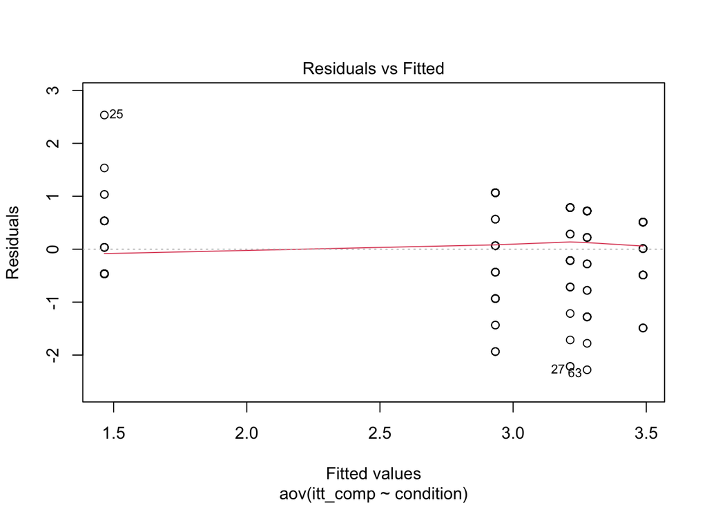

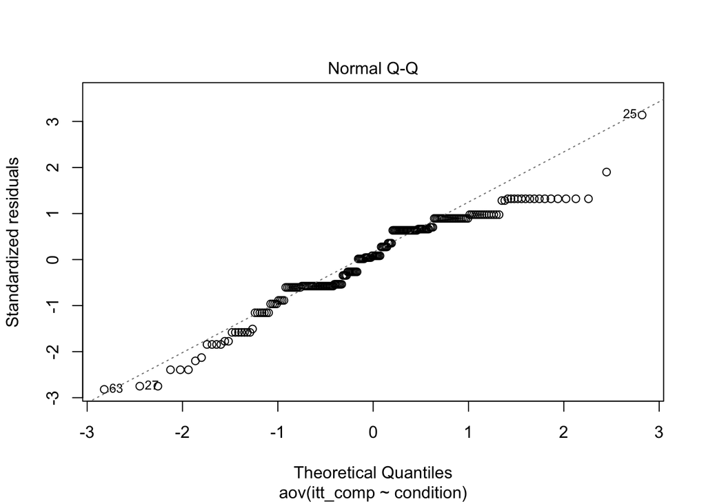

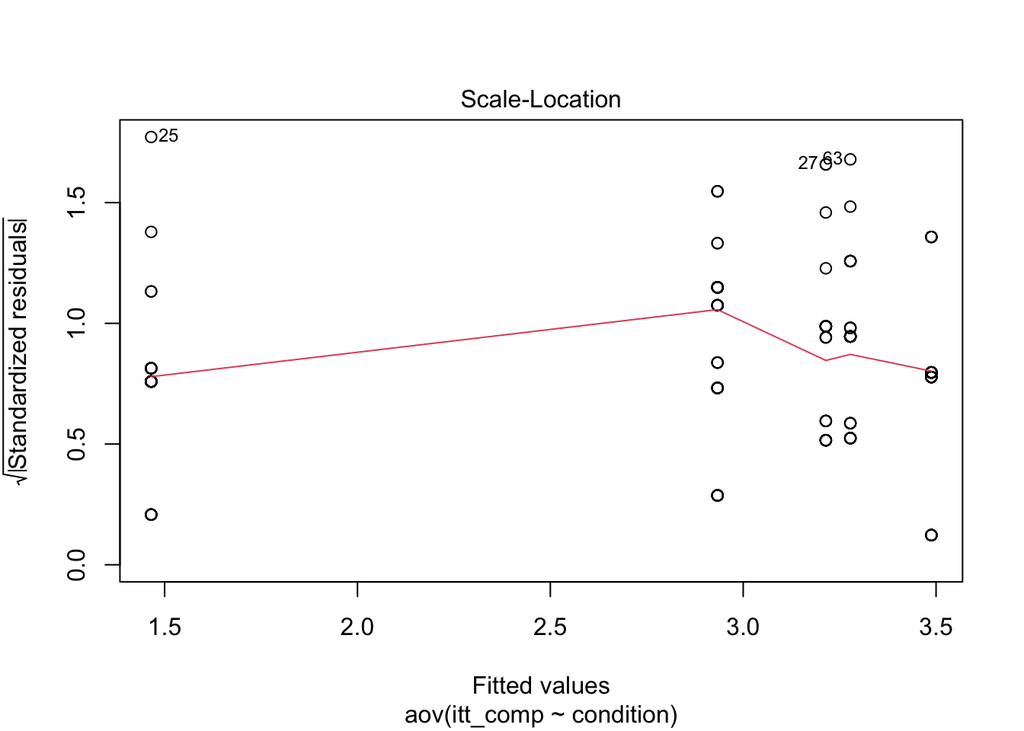

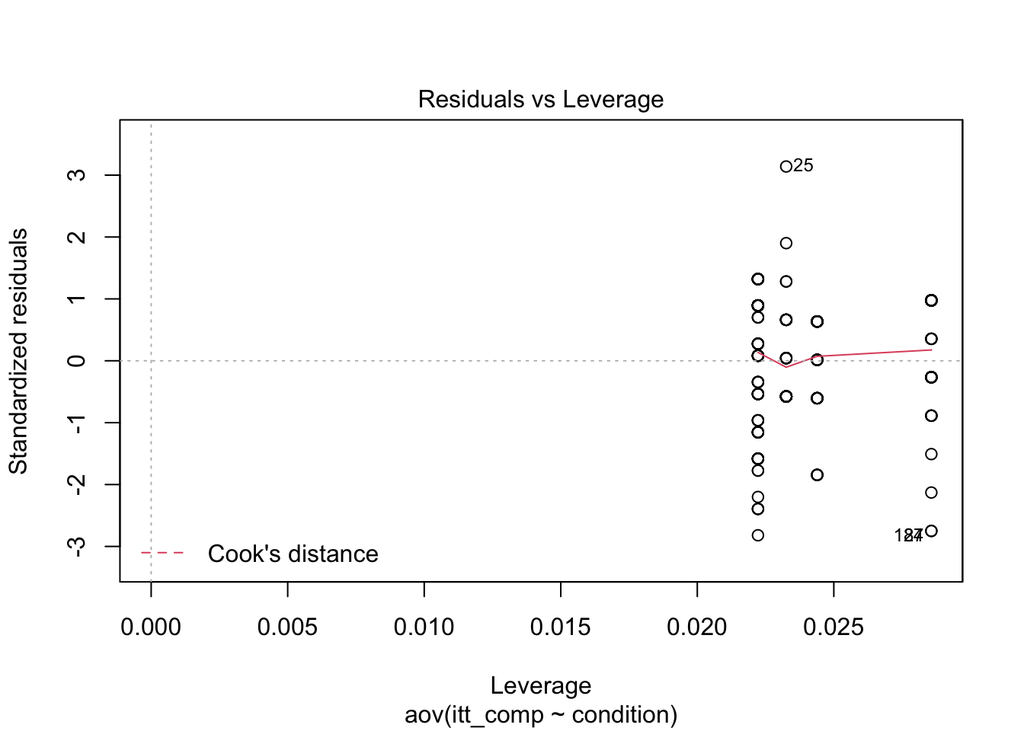

```r
plot(results)
```

A little weird, but working with categorical variables. The QQ especially suggests some non-normality of residuals, but regression odels are robust to violations of normality and heteroscedastisticity.

#### Post-hoc test

```r
emmeans(results, pairwise ~ condition)
```

```
## $emmeans
##  condition    emmean    SE  df lower.CL upper.CL
##  control_targ   1.47 0.125 204     1.22     1.71
##  warm_targ      2.93 0.122 204     2.69     3.17
##  covid_targ     3.28 0.122 204     3.04     3.52
##  comp_targ      3.21 0.138 204     2.94     3.49
##  loss_targ      3.49 0.128 204     3.24     3.74
##
## Confidence level used: 0.95
##
## $contrasts
##  contrast                  estimate    SE  df t.ratio p.value
##  control_targ - warm_targ   -1.4682 0.174 204  -8.427  <.0001
##  control_targ - covid_targ  -1.8127 0.174 204 -10.404  <.0001
##  control_targ - comp_targ   -1.7492 0.186 204  -9.405  <.0001
##  control_targ - loss_targ   -2.0227 0.178 204 -11.342  <.0001
##  warm_targ - covid_targ     -0.3444 0.172 204  -2.000  0.2698
##  warm_targ - comp_targ      -0.2810 0.184 204  -1.526  0.5469
##  warm_targ - loss_targ      -0.5545 0.176 204  -3.144  0.0163
##  covid_targ - comp_targ      0.0635 0.184 204   0.345  0.9969
##  covid_targ - loss_targ     -0.2100 0.176 204  -1.191  0.7567
##  comp_targ - loss_targ      -0.2735 0.188 204  -1.455  0.5930
##
## P value adjustment: tukey method for comparing a family of 5 estimates
```

Control differs from warm targ, covid targ, comp targ, and loss targ Loss targ and warm targ also differ from one another

The warm targ and comp targ do not differ (somewhat applicable to Study 1, but not post-hoc or female vs male)

## Distance coffee

### ANOVA

#### Summary results

```r
results_coffee <- aov(distance_coffee ~ condition, data = clean_data)
summary(results_coffee)
```

```
##              Df Sum Sq Mean Sq F value    Pr(>F)
## condition     4  22.28   5.569   6.702 0.0000436 ***
## Residuals   204 169.52   0.831
## ---
## Signif. codes:  0 '***' 0.001 '**' 0.01 '*' 0.05 '.' 0.1 ' ' 1
```

#### Residuals

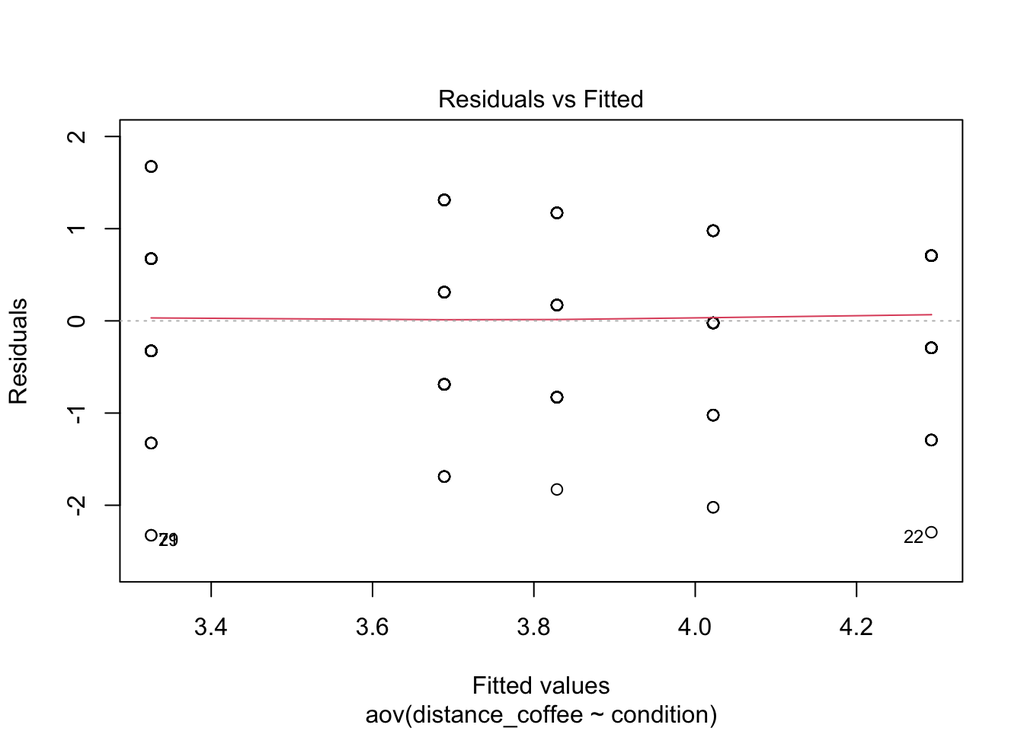

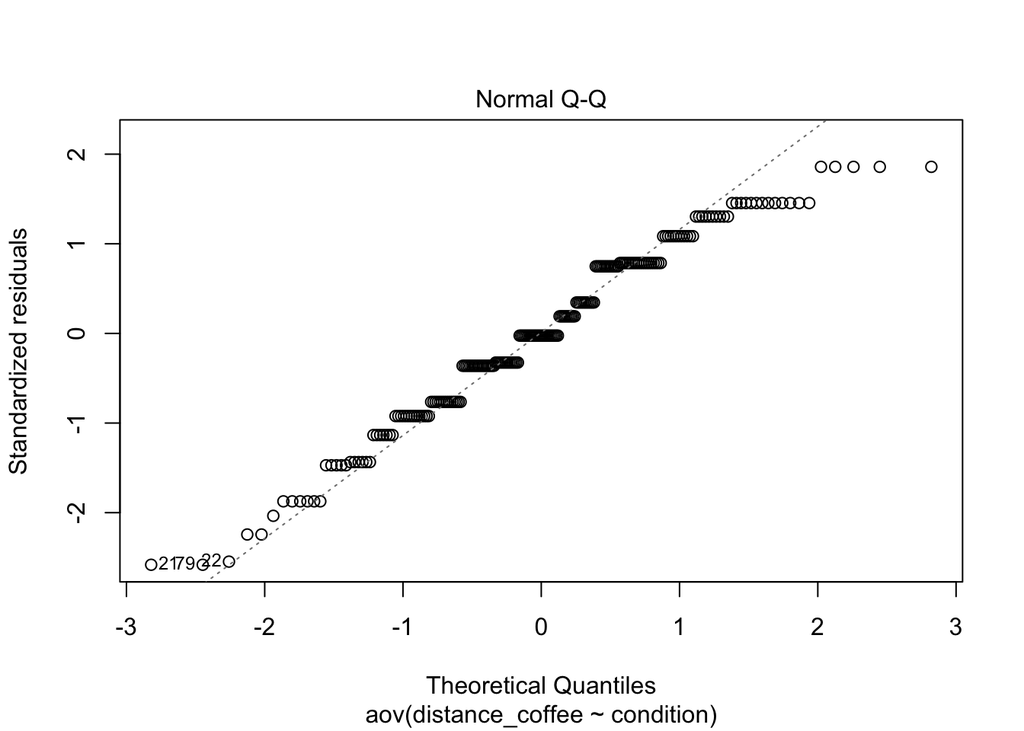

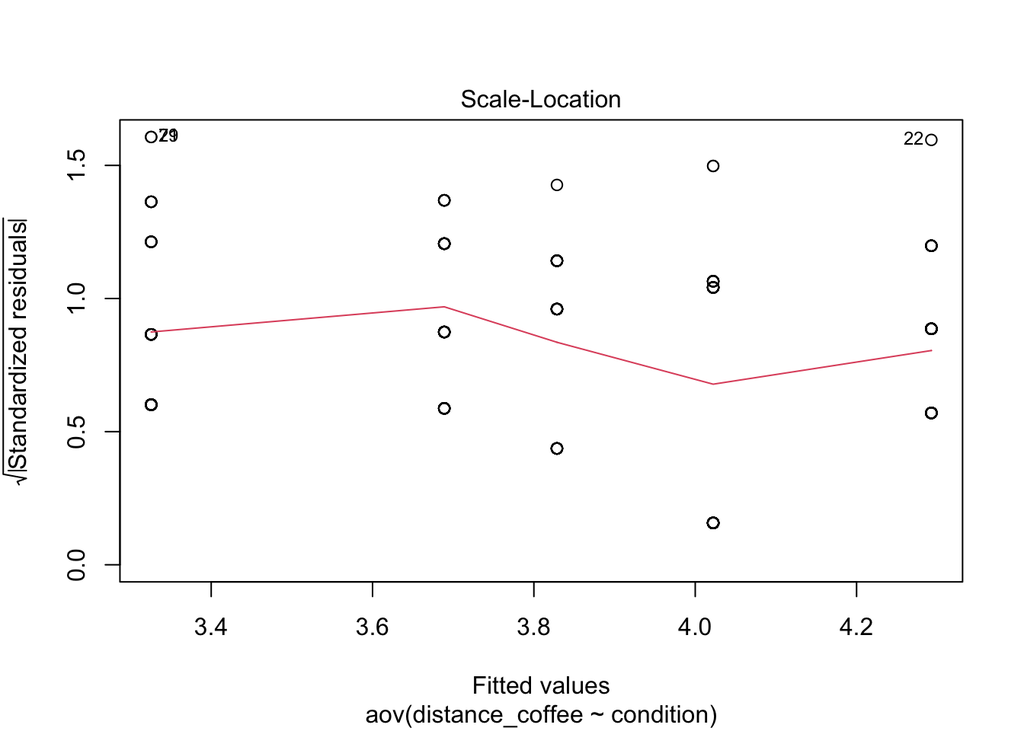

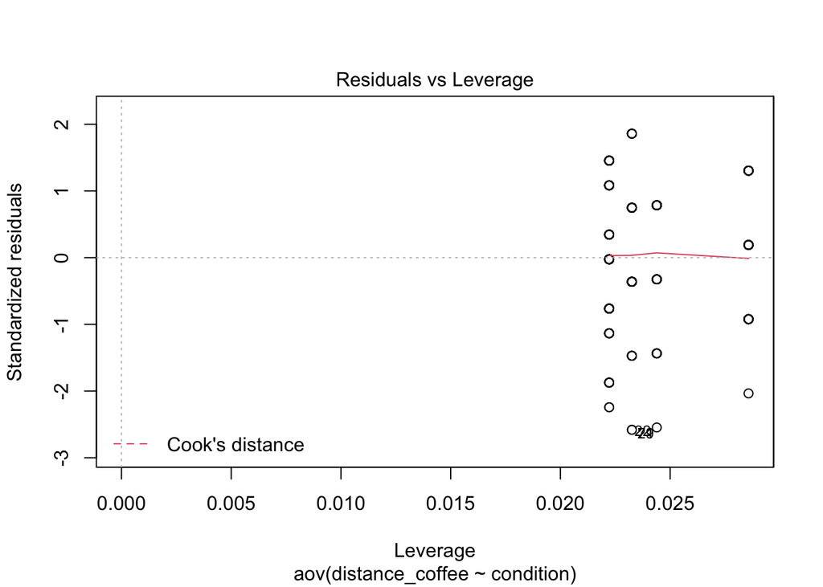

```r
plot(results_coffee)
```

Residuals and QQ look a little more normal than wwith the threat composite. Same reasoning here to assume regression is robst to violations.

#### Marginal means & pairwise

```r
emmeans(results_coffee, pairwise ~ condition)
```

```
## $emmeans
##  condition    emmean    SE  df lower.CL upper.CL
##  control_targ   3.33 0.139 204     3.05     3.60
##  warm_targ      3.69 0.136 204     3.42     3.96
##  covid_targ     4.02 0.136 204     3.75     4.29
##  comp_targ      3.83 0.154 204     3.52     4.13
##  loss_targ      4.29 0.142 204     4.01     4.57
##
## Confidence level used: 0.95
##
## $contrasts
##  contrast                  estimate    SE  df t.ratio p.value
##  control_targ - warm_targ    -0.363 0.194 204  -1.869  0.3375
##  control_targ - covid_targ   -0.697 0.194 204  -3.584  0.0038
##  control_targ - comp_targ    -0.503 0.208 204  -2.424  0.1132
##  control_targ - loss_targ    -0.967 0.199 204  -4.860  <.0001
##  warm_targ - covid_targ      -0.333 0.192 204  -1.734  0.4152
##  warm_targ - comp_targ       -0.140 0.205 204  -0.680  0.9606
##  warm_targ - loss_targ       -0.604 0.197 204  -3.068  0.0205
##  covid_targ - comp_targ       0.194 0.205 204   0.943  0.8799
##  covid_targ - loss_targ      -0.270 0.197 204  -1.374  0.6449
##  comp_targ - loss_targ       -0.464 0.210 204  -2.212  0.1793
##
## P value adjustment: tukey method for comparing a family of 5 estimates
```

Loss and covid differ from control; loss also differs from warm; warm and control did not differ

## Distance town

### ANOVA

#### Summary results

```r
results_town <- aov(distance_town ~ condition, data = clean_data)
summary(results_town)
```

```
##              Df Sum Sq Mean Sq F value  Pr(>F)
## condition     4   37.3   9.321   3.627 0.00703 **
## Residuals   204  524.3   2.570
## ---
## Signif. codes:  0 '***' 0.001 '**' 0.01 '*' 0.05 '.' 0.1 ' ' 1
```

#### Residuals

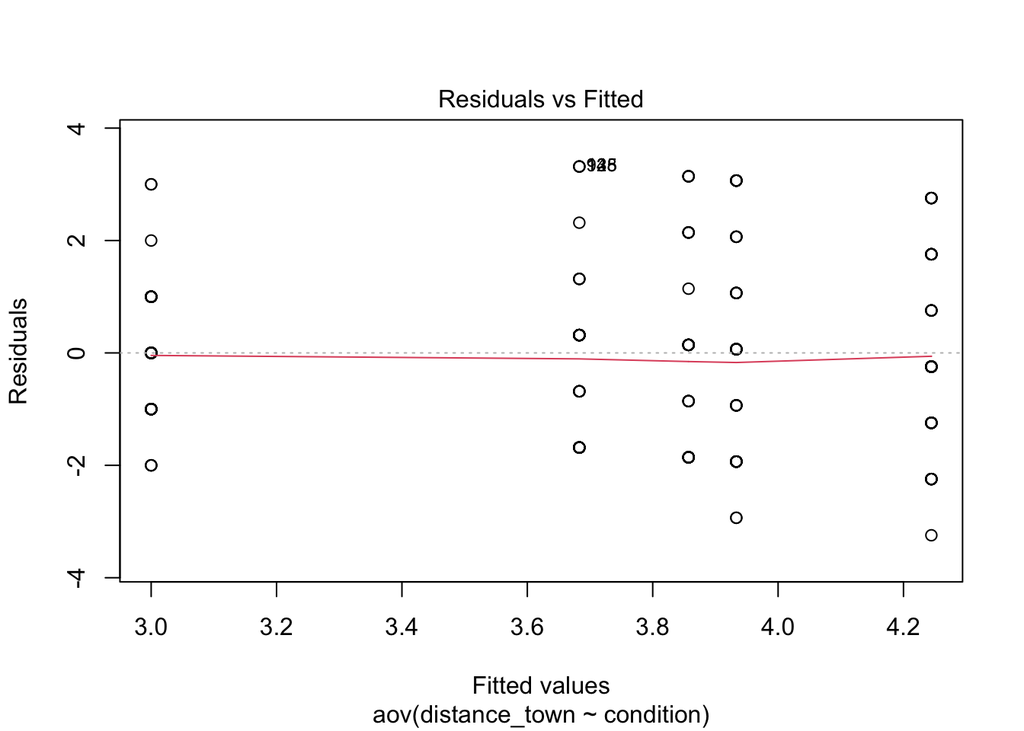

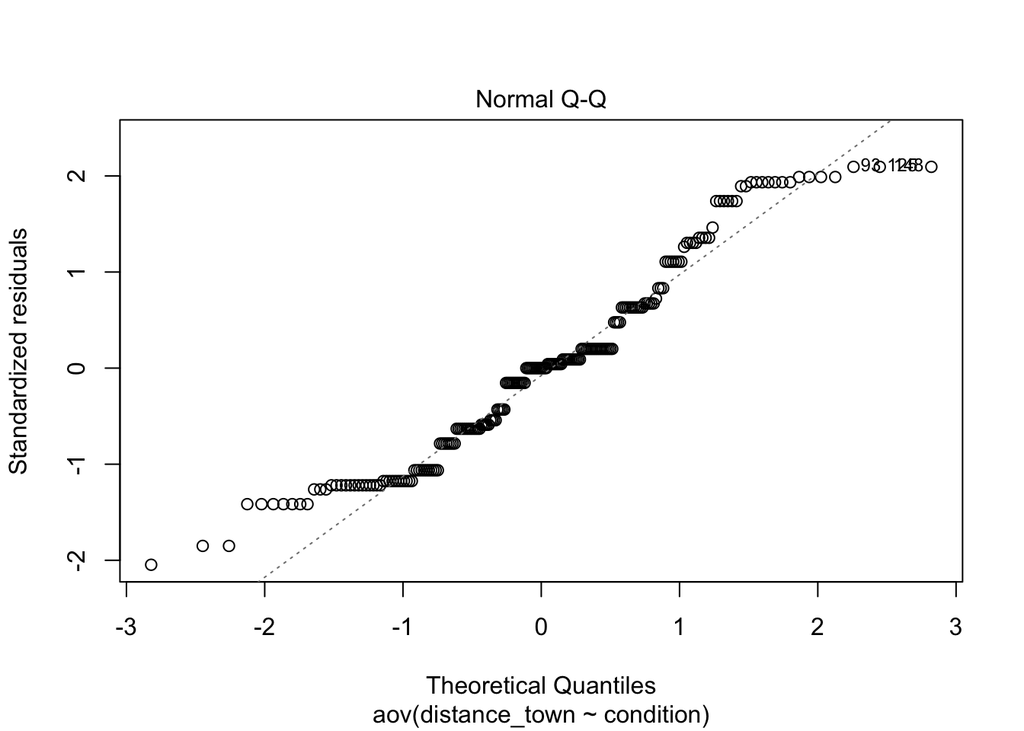

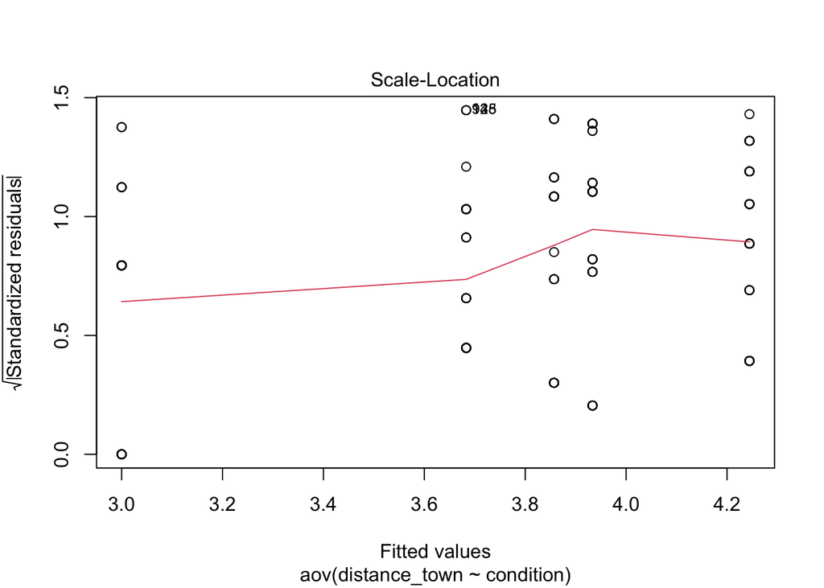

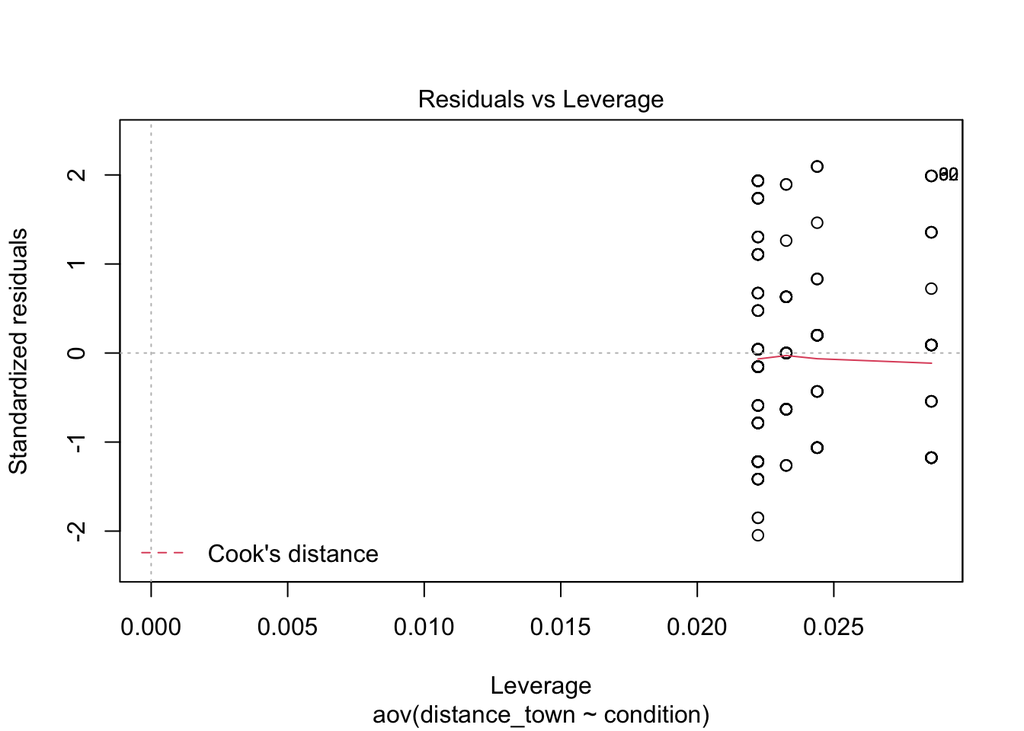

```r
plot(results_town)
```

QQ suggests some non-normality, but regression is robust to violations of normality.

#### Marginal means & pairwise

```r
emmeans(results_town, pairwise ~ condition)
```

```
## $emmeans
##  condition    emmean    SE  df lower.CL upper.CL
##  control_targ   3.00 0.244 204     2.52     3.48
##  warm_targ      4.24 0.239 204     3.77     4.72
##  covid_targ     3.93 0.239 204     3.46     4.40
##  comp_targ      3.86 0.271 204     3.32     4.39
##  loss_targ      3.68 0.250 204     3.19     4.18
##
## Confidence level used: 0.95
##
## $contrasts
##  contrast                  estimate    SE  df t.ratio p.value
##  control_targ - warm_targ   -1.2444 0.342 204  -3.640  0.0032
##  control_targ - covid_targ  -0.9333 0.342 204  -2.730  0.0530
##  control_targ - comp_targ   -0.8571 0.365 204  -2.349  0.1341
##  control_targ - loss_targ   -0.6829 0.350 204  -1.952  0.2937
##  warm_targ - covid_targ      0.3111 0.338 204   0.921  0.8887
##  warm_targ - comp_targ       0.3873 0.361 204   1.072  0.8207
##  warm_targ - loss_targ       0.5615 0.346 204   1.622  0.4849
##  covid_targ - comp_targ      0.0762 0.361 204   0.211  0.9996
##  covid_targ - loss_targ      0.2504 0.346 204   0.723  0.9509
##  comp_targ - loss_targ       0.1742 0.369 204   0.472  0.9898
##
## P value adjustment: tukey method for comparing a family of 5 estimates
```

# Explicit measures

## EFA

```r
explicit_2 <- clean_data %>%
  select(explicit_targ, explicit_group)

explicit_1fac <- psych::fa(explicit_2, nfactors = 1)

explicit_1fac %>%
  model_parameters(sort = TRUE, threshold = "max")
```

```
## # Rotated loadings from Factor Analysis (oblimin-rotation)
##
## Variable       | MR1  | Complexity | Uniqueness
## -----------------------------------------------
## explicit_group | 0.77 |    1.00    |    0.41
## explicit_targ  | 0.77 |    1.00    |    0.41
##
## The unique latent factor (oblimin rotation) accounted for 59.27% of the total variance of the original data.
```

### Alpha

```r
psych::alpha(explicit_2)
```

```
##
## Reliability analysis
## Call: psych::alpha(x = explicit_2)
##
##   raw_alpha std.alpha G6(smc) average_r S/N   ase mean   sd median_r
##       0.73      0.74    0.59      0.59 2.9 0.036  2.8 0.91     0.59
##
##     95% confidence boundaries
##          lower alpha upper
## Feldt     0.65  0.73   0.8
## Duhachek  0.67  0.73   0.8
##
##  Reliability if an item is dropped:
##                raw_alpha std.alpha G6(smc) average_r S/N alpha se var.r med.r
## explicit_targ       0.73      0.59    0.35      0.59 1.5       NA     0  0.59
## explicit_group      0.48      0.59    0.35      0.59 1.5       NA     0  0.59
##
##  Item statistics
##                  n raw.r std.r r.cor r.drop mean   sd
## explicit_targ  209  0.91  0.89  0.69   0.59  2.4 1.12
## explicit_group 209  0.87  0.89  0.69   0.59  3.1 0.91
##
## Non missing response frequency for each item
##                   1    2    3    4 miss
## explicit_targ  0.28 0.28 0.22 0.22    0
## explicit_group 0.05 0.22 0.30 0.43    0
```

## Descriptives

### Composite explicit measure

```r
clean_data %<>%
  mutate(explicit_comp = rowMeans(select(., c("explicit_targ", "explicit_group"))))
```

#### Mean

```r
mean(clean_data$explicit_comp)
```

```
## [1] 2.751196
```

#### SD

```r
sd(clean_data$explicit_comp)
```

```
## [1] 0.9068707
```

#### Range

```r
range(clean_data$explicit_comp)
```

```
## [1] 1 4
```

### Correlation with ITT composite

```r
cor_threat_comps <- clean_data %>%
  select(itt_comp, explicit_comp)

cor <- cor(cor_threat_comps)
cor.test(cor_threat_comps$itt_comp, cor_threat_comps$explicit_comp, methdo = "pearson")
```

```
##
##  Pearson's product-moment correlation
##
## data:  cor_threat_comps$itt_comp and cor_threat_comps$explicit_comp
## t = 13.449, df = 207, p-value < 0.00000000000000022
## alternative hypothesis: true correlation is not equal to 0
## 95 percent confidence interval:
##  0.6030390 0.7491537
## sample estimates:
##      cor
## 0.682867
```

Explicit threat and ITT measures are highly correlated. This provides additional validation.

## ANOVA

#### Summary results

```r
results_explicit <- aov(explicit_comp ~ condition, data = clean_data)
summary(results_explicit)
```

```
##              Df Sum Sq Mean Sq F value      Pr(>F)
## condition     4  27.55   6.889   9.793 0.000000289 ***
## Residuals   204 143.51   0.703
## ---
## Signif. codes:  0 '***' 0.001 '**' 0.01 '*' 0.05 '.' 0.1 ' ' 1
```

#### Residuals

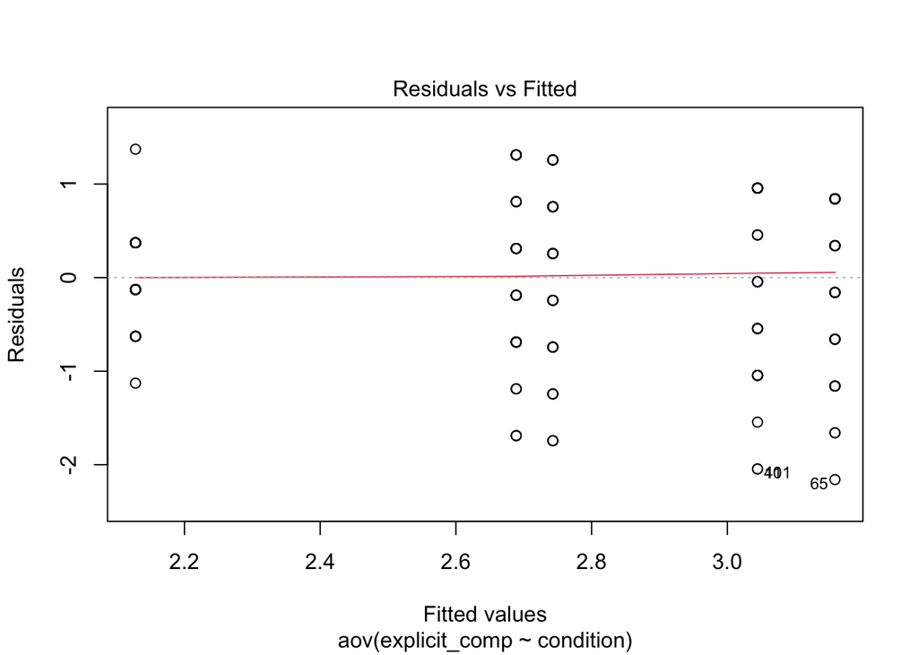

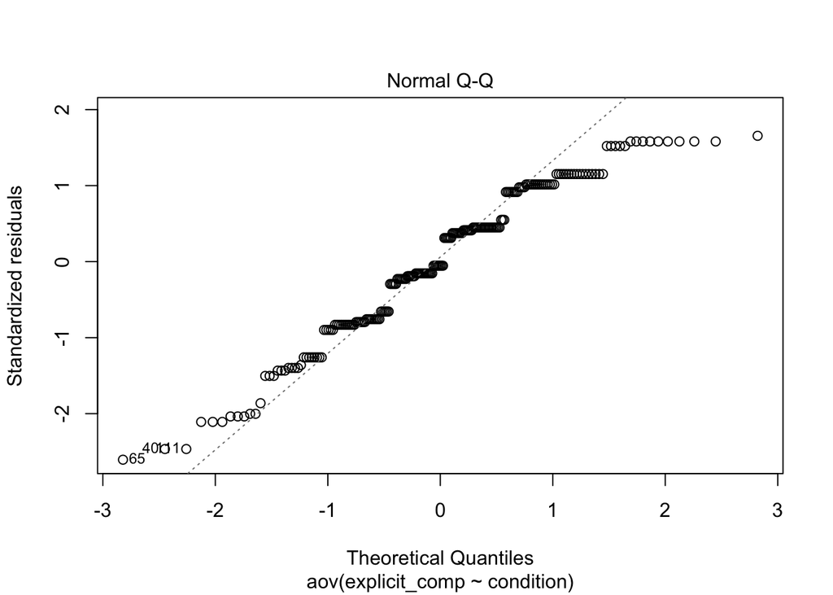

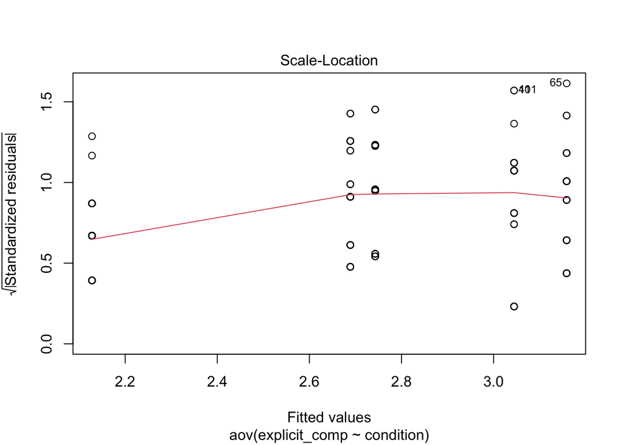

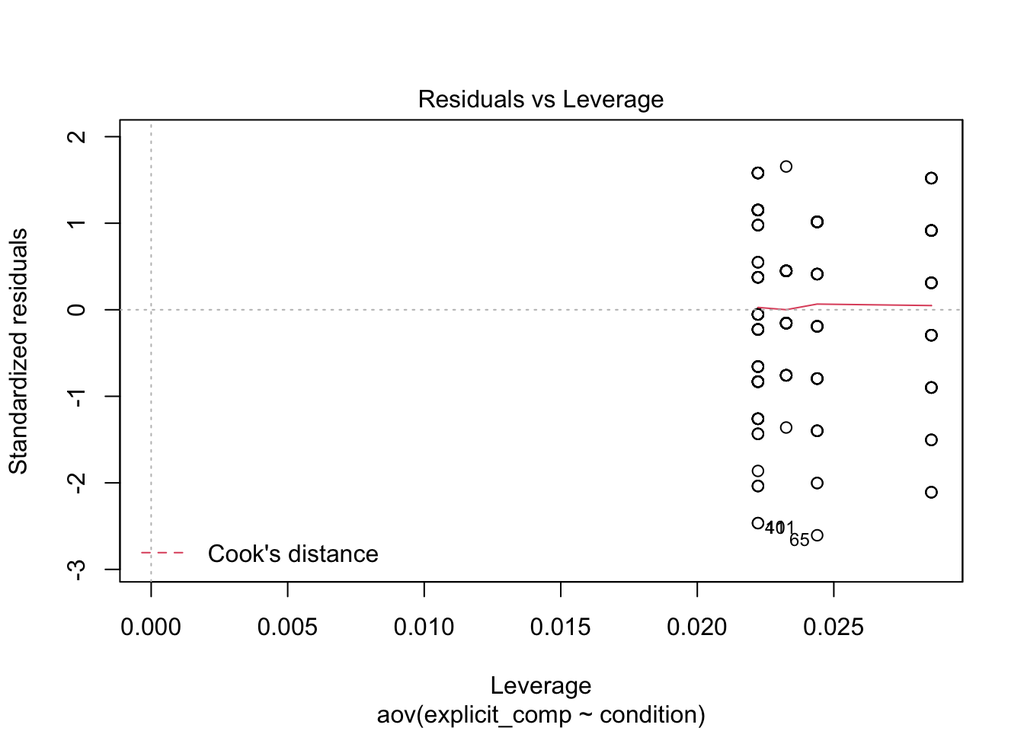

```r
plot(results_explicit)
```

QQ suggests some non-normality (as with the other measures), but regression models are often robust to violations.

#### Marginal means & pairwise

```r
emmeans(results_explicit, pairwise ~ condition)
```

```
## $emmeans
##  condition    emmean    SE  df lower.CL upper.CL
##  control_targ   2.13 0.128 204     1.88     2.38
##  warm_targ      2.69 0.125 204     2.44     2.94
##  covid_targ     3.04 0.125 204     2.80     3.29
##  comp_targ      2.74 0.142 204     2.46     3.02
##  loss_targ      3.16 0.131 204     2.90     3.42
##
## Confidence level used: 0.95
##
## $contrasts
##  contrast                  estimate    SE  df t.ratio p.value
##  control_targ - warm_targ    -0.561 0.179 204  -3.136  0.0166
##  control_targ - covid_targ   -0.917 0.179 204  -5.124  <.0001
##  control_targ - comp_targ    -0.615 0.191 204  -3.221  0.0128
##  control_targ - loss_targ    -1.031 0.183 204  -5.629  <.0001
##  warm_targ - covid_targ      -0.356 0.177 204  -2.011  0.2645
##  warm_targ - comp_targ       -0.054 0.189 204  -0.286  0.9985
##  warm_targ - loss_targ       -0.470 0.181 204  -2.594  0.0753
##  covid_targ - comp_targ       0.302 0.189 204   1.595  0.5020
##  covid_targ - loss_targ      -0.114 0.181 204  -0.630  0.9701
##  comp_targ - loss_targ       -0.416 0.193 204  -2.154  0.2018
##
## P value adjustment: tukey method for comparing a family of 5 estimates
```